# Maxent ENM using BioClim and Land Use data

Pablo Deschepper

2024-12-02

[figure not shown]

*This Markdown script was developed to model ecological niches under both current and future climate conditions. The ecological niche models (ENMs) for present-day conditions are trained using BioClim data, land use data, or a combination of both. For future projections, the models use BioClim data based on climate projections alone or combined with contemporary land use data.*  
*The modeled distributions reflect the species’ ecological niche, although several factors—such as dispersal barriers, geological history, and biotic interactions—may create differences between the realized and modeled niches.*  
*The script allows flexible model training, enabling users to specify geographic boundaries (country or continent) for occurrence data. Users can visualize the predicted species distribution or ecological niche within customized coordinate ranges, making this tool adaptable to various research needs. The script automatically removes strongly correlated (r > 0.75) predictors within the range of the species occurrences.*

- **Species = *Vipera berus***
- Using records from following database: gbif
- The number of records is limited to 1500 records
- Climate model for future predictions: MPI-ESM1-2-HR
- Shared Socioeconomic Pathway (SSP): 585

The working directory = *D:/temp/SDM_Herpetofauna/Maxent_HighRes_SSP245SSP585/*

note: The script will download all BioClim and Land Use data upon first use of the script, translating into a longer processing times. The script will run faster after first use.

## Species records

This plot shows the georeferenced species records that will be used to train the Ecological Niche model (ENM) using MaxEnt. It is good to maximize the number of records. When the option of the species’ range map is toggled, a range map is plotted by an alpha hull polygon.

**1500 records** of Vipera berus are used for processing (georeference obscurity < 500m).

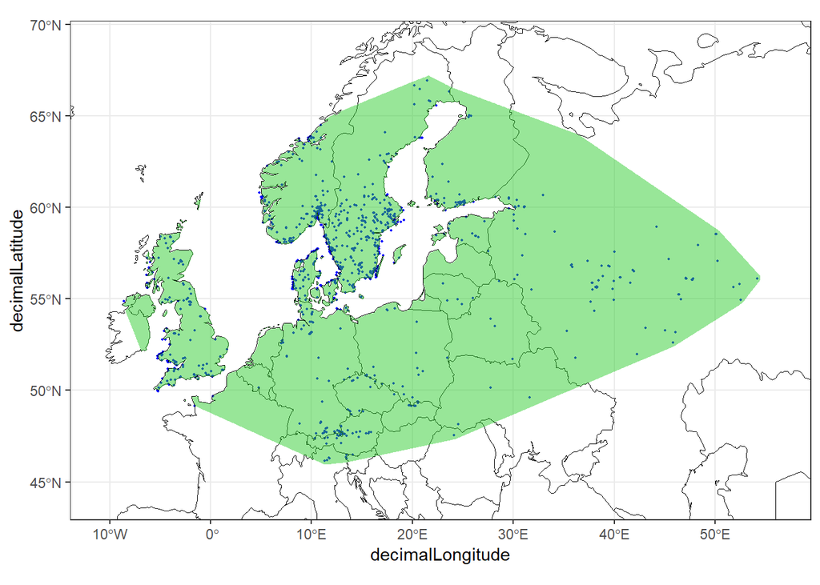

# MaxEnt ENM: the models

## Predictor contributions for every model

- *Full model*: This model includes all 19 BioClim variables all land use variables as predictors.
- *BioClim model*: This model exclusively uses the BioClim variables to train the model.
- *Land Use model*: This model exclusively uses the land use variables to train the model.

All models are employed with 10-fold cross validation. The ENMevaluate function from the ENMeval package was used to tune parameters: tune.args = list(fc = c(“L”, “Q”, “LQ”), rm = seq(0.5, 2, 0.5)).

**BioClimatic variables**  
BIO1 = Annual Mean Temperature  
BIO2 = Mean Diurnal Range (Mean of monthly (max temp - min temp))  
BIO3 = Isothermality (BIO2/BIO7) (×100)  
BIO4 = Temperature Seasonality (standard deviation ×100)  
BIO5 = Max Temperature of Warmest Month  
BIO6 = Min Temperature of Coldest Month  
BIO7 = Temperature Annual Range (BIO5-BIO6)  
BIO8 = Mean Temperature of Wettest Quarter  
BIO9 = Mean Temperature of Driest Quarter  
BIO10 = Mean Temperature of Warmest Quarter  
BIO11 = Mean Temperature of Coldest Quarter  
BIO12 = Annual Precipitation  
BIO13 = Precipitation of Wettest Month  
BIO14 = Precipitation of Driest Month  
BIO15 = Precipitation Seasonality (Coefficient of Variation)  
BIO16 = Precipitation of Wettest Quarter  
BIO17 = Precipitation of Driest Quarter  
BIO18 = Precipitation of Warmest Quarter  
BIO19 = Precipitation of Coldest Quarter

**Land use variables**  
Values are the fraction of a landcover class in each cell. The values are derived from the ESA WorldCover data set at 0.3-seconds resolution.  
Landcover variables:  
- Trees  
- Grassland  
- Shrubs  
- Water  
- Wetland  
- Bare  
- Built

more info on: https://github.com/rspatial/geodata

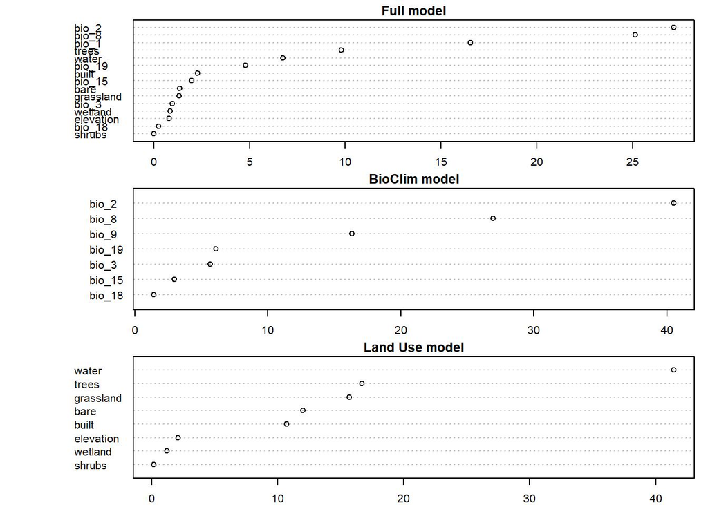

Predictors within every model have been purged for correlation if r > 0.75. When pairwise correlation is detected above this threshold, one of the variables within the pair is omitted before further processing.

### Partial response curve

For each predictor the fitted species-environment relationship is plotted along the entire gradient while keeping the other predictors at their mean value. Partial response plots are oversimplifications and therefore hard to interpret as they do not represent the full species-environment relationship.

#### Full model

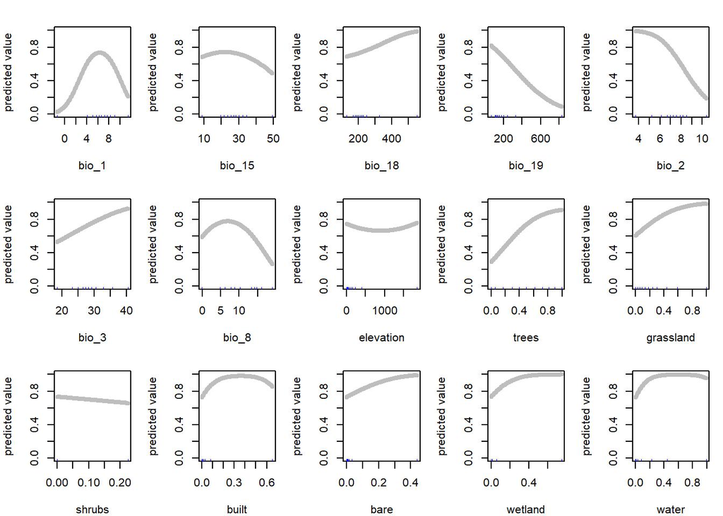

#### BioClim model

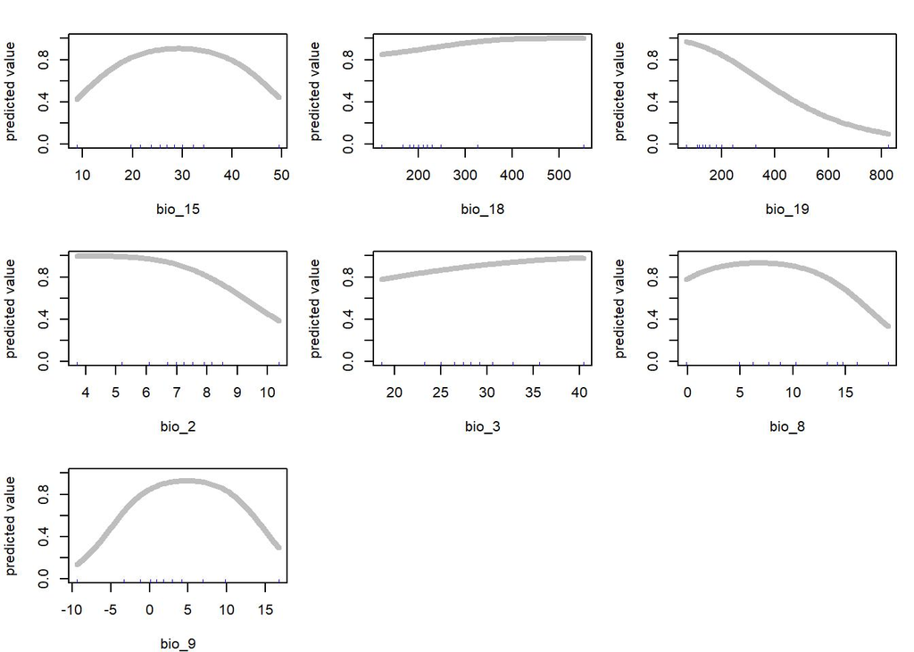

#### Land Use model

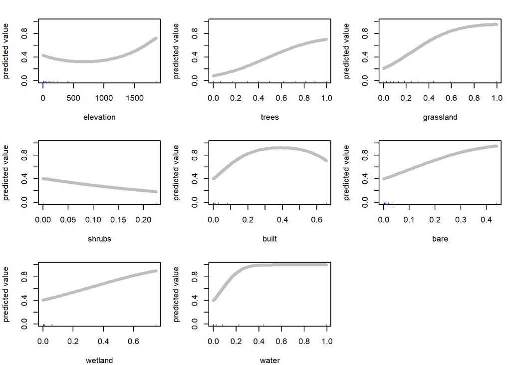

## Model validation

In order to validate the models and make a comparison between the three models trained on different predictor sets, 75% of the data is kept to train the MaxEnt (Maximum Entropy) models, while the remaining 25% is kept aside for model validation. The ROC curve is drawn by calculating the true positive rate (TPR) and false positive rate (FPR) at every possible threshold. A perfect model has a TPR of 1.0 and a FPR of 0.0. The larger the Area Under the Curve (AUC), the better a model performs.

[figure not shown]

Metrics for model evaluation:

```
## $`Full model`
## class          : ModelEvaluation
## n presences    : 293
## n absences     : 1994
## AUC            : 0.8965069
## cor            : 0.5437737
## max TPR+TNR at : 0.4009705
##
## $`BioClim model`
## class          : ModelEvaluation
## n presences    : 296
## n absences     : 2000
## AUC            : 0.8529088
## cor            : 0.4619844
## max TPR+TNR at : 0.5187287
##
## $`Land use model`
## class          : ModelEvaluation
## n presences    : 293
## n absences     : 2000
## AUC            : 0.8336578
## cor            : 0.4066422
## max TPR+TNR at : 0.5098017
```

# MaxEnt ENM: plots

## Present

### ENM using BioClim and land use data

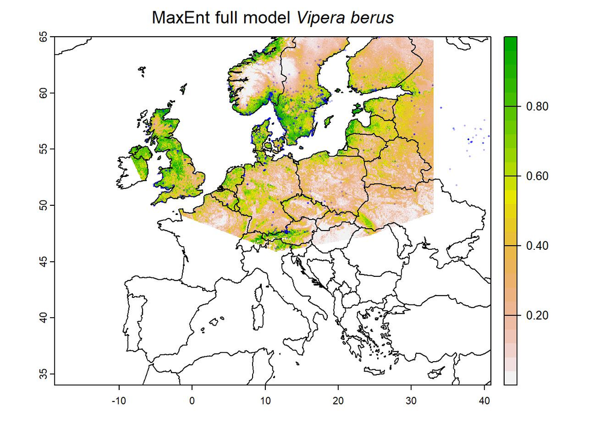

### ENM using BioClim data only

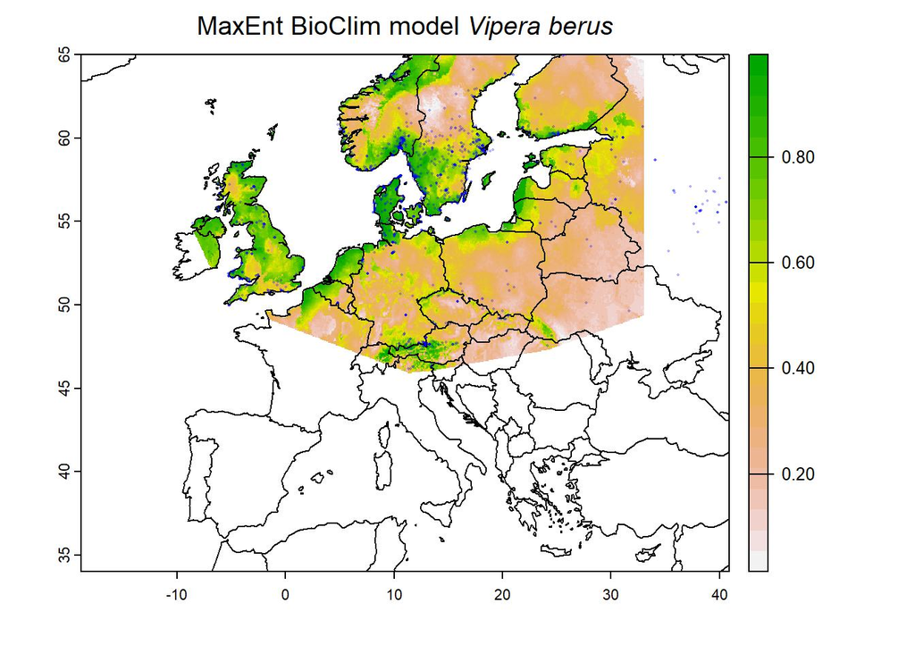

### ENM using land use data only

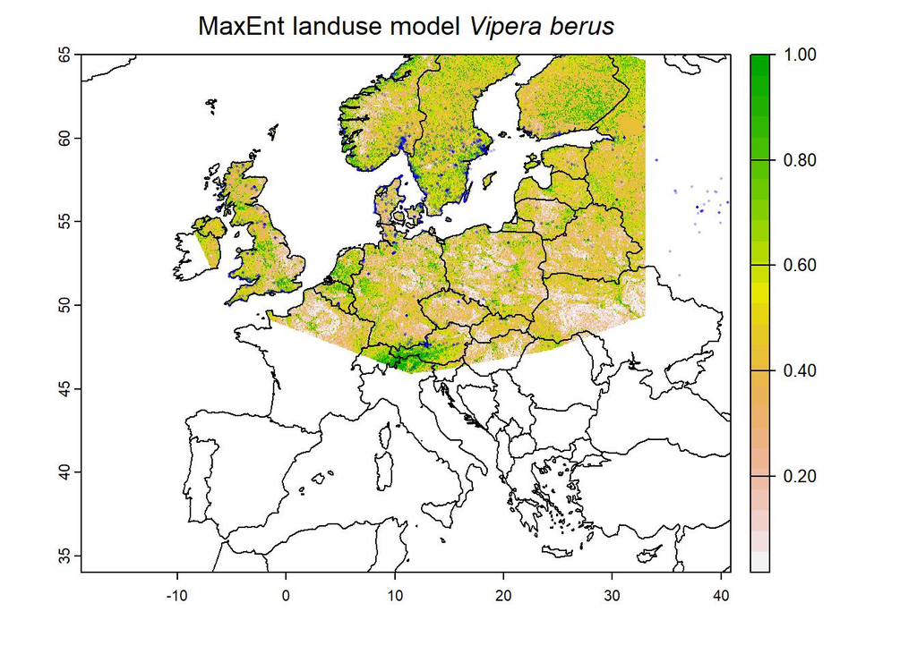

## Future

### ENM using future BioClim data and contemporary land use data combined

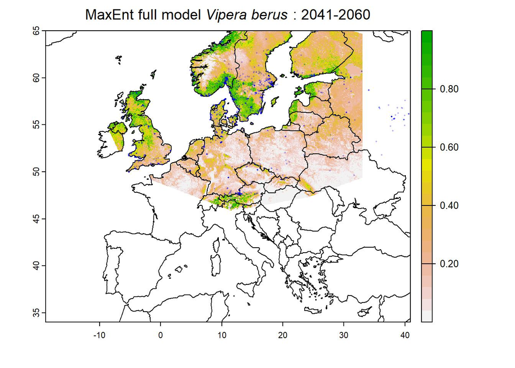

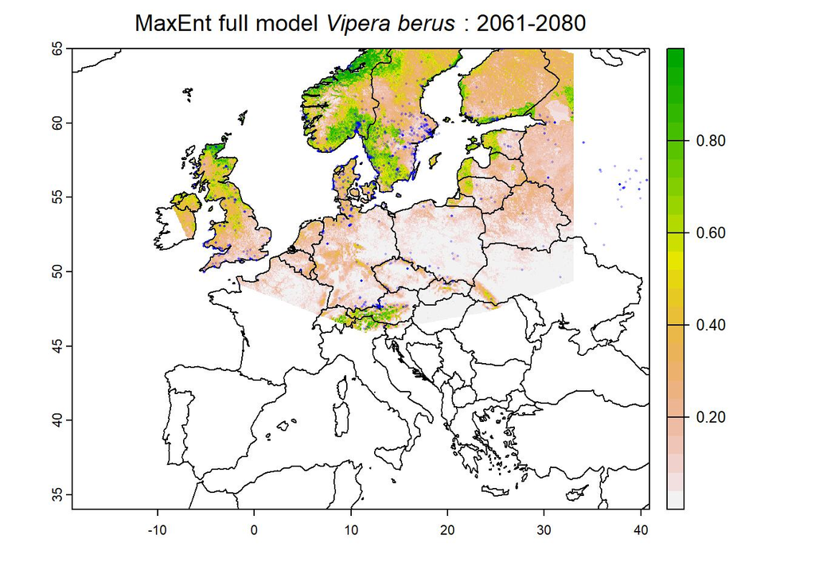

### ENM using future BioClim data

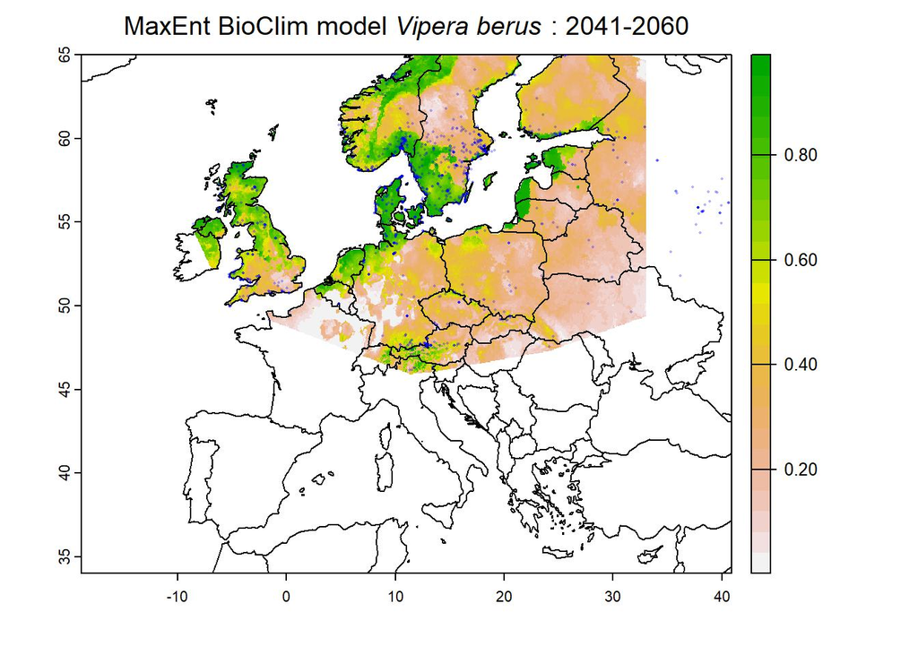

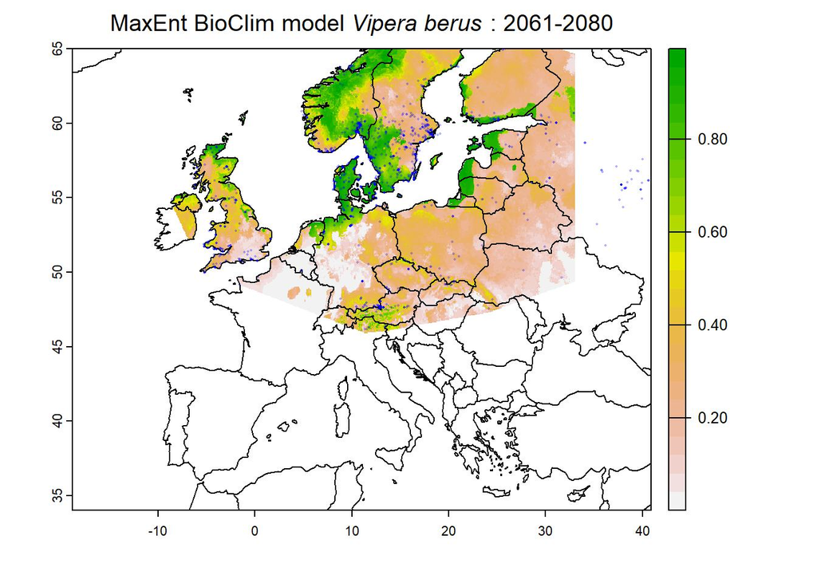

## ENM change

### Change in climatic niche

Change in climatic niche availability using BioClim predictors between the current climate and future climate. Increase in climatic niche size is indicated in blue, reduction is indicated in red. Additionally, a trend plot is shown that indicates the change in climatic suitability. For every grid cell of 5x5km that has at least one species record, the average value of change is calculated. Density plots give context to the variability across sites. Averaging values across grid cells mitigates biased results towards extensively visited regions.

```
## |---------|---------|---------|---------|=========================================
```

```
## |---------|---------|---------|---------|=========================================
```

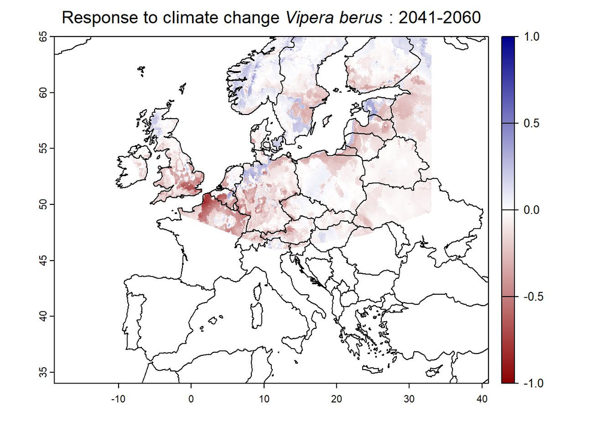

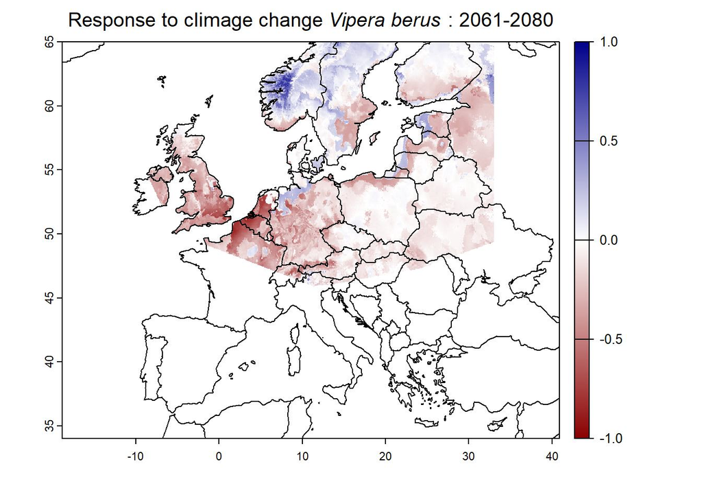

[figure not shown]

## Limiting variables

### Calculate a limiting factor surface

The variable most responsible for unfavorable conditions in respect of the species’ climatic niche in the future (2041-2060) is plotted for every grid cell within the range specified by the user.

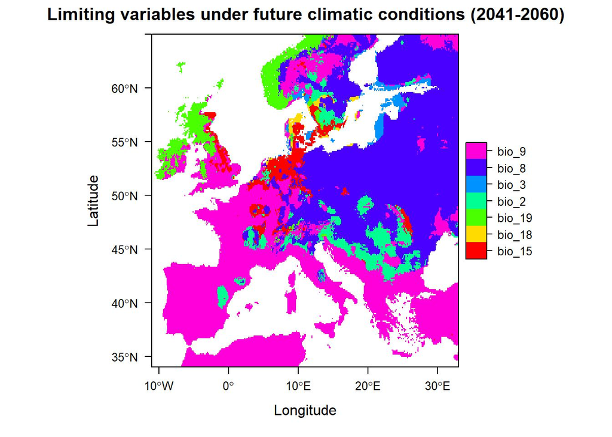

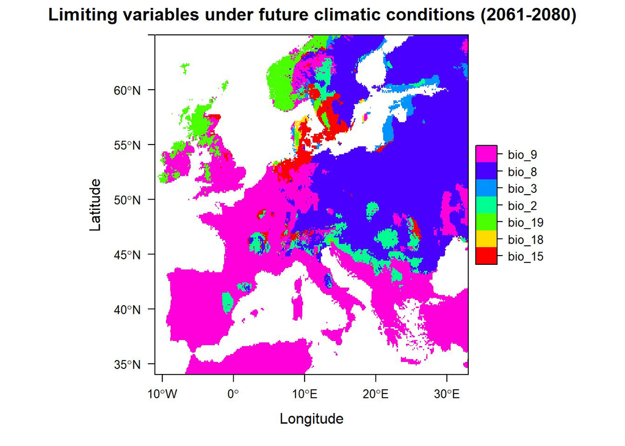

This table shows the relative contribution of every BioClim predictor to the species’ climatic niche contraction where the strength of range reducion is > -0.1. (present vs 2041-2060). The relative contribution is estimated by:  
1) Extracting the limiting predictor variables that overlap with a value lower than -0.1 for range contraction.  
2) Overlaying the species’ spatial occurrence points with the extracted raster image from step 1 and count the relative contribution of every predictor variable.

Relative Contribution of Predictors for Negative Change Areas

| Predictor | Freq | Perc |
| --- | --- | --- |
| bio_8 | 292 | 42.44 |
| bio_9 | 169 | 24.56 |
| bio_3 | 99 | 14.39 |
| bio_19 | 50 | 7.27 |
| bio_15 | 38 | 5.52 |
| bio_18 | 33 | 4.80 |
| bio_2 | 7 | 1.02 |